# Projet ADM total

RODRIGUES Camille-Astrid AMOUROUX Jan

2025-04-03

# ==== QUESTION 1 ====

**/!\ WARNING** : chi² –> test d’indépendance : H0 “Les données sont indépendantes”. La p-value correspond au risque de se tromper en rejettant H0. Donc si p>0.05 –> on ne rejette pas H0, les données sont indépendantes, pas de relation entre elles ni d’implication. Donc si p<=0.05 –> on rejette H0, les données sont dépendantes, il existe une relation entre elles.

```r
library(tidyverse)
library(ade4)
library(vegan)
```

–> communautés : quelles sont les espèces qui vivent ensemble ? même localisation ? exemple : Est-ce que pinson toujours avec pie ? –> habitat : différentes répartitions selon la localisation ? exemple : Quand il fait chaud, les pinsons ne blairent plus les pies ?

==> impact de l’environnement sur la répartition des espèces –> interactions ou évitements

**ANALYSE** : ==> test du Chi² pour vérifier la dépendance entre les données localisations et présence de l’espèce ==> ACM(commu) : nous avons des données utilisant des modalités simples avec j individus et i localisations ==> expected : groupes d’oiseaux, oiseaux “ubiquitaires” ==> test corrélation des variables entre-elles pour diminuer le nombre de variables à étudier ==> ACP(habitat) : lissage des données qualitatives au besoin, réduction du nombre de variables ==> co-inertie = ACM+ACP : couplage de tableaux entre habitat et répartition espèces ==> expected : présence de cluster en fonction de certaines caractéristiques du milieu

==> conclure : comportements différents selon la qualité de vie du milieu (caractéristiques ciblées par l’analyse)

suite analyse pour q3

# Ouverture des documents

```r
habitat = read.table("../data/habitat.tsv", sep = "\t",
                     stringsAsFactors = T, header = T, na.strings = T)
especes = read.table("../data/especes.tsv", sep = "\t",
                     stringsAsFactors = T, header = T, na.strings = T)
commu = read.table("../data/communautes.tsv", sep = "\t",
                     stringsAsFactors = T, header = T, na.strings = T)
```

# Test du X² : indépendance entre présence de l’espèce et caractéristiques du milieu ?

```r
#test de la répartition d'une espèce d'oiseau en fonction de l'environnement
commu_clean = commu[,-1]
habitat_clean = habitat[,-1]
esp = colnames(commu_clean[1,])
hab = colnames(habitat_clean[1,])

write(x = "Test de chi2 sur la répartition d'une espèce d'oiseau en fonction de l'environnement", file = "chi-2_q1_export.txt", append = F)
n=0
for (i in 1:length(commu_clean[1,])){
  n=n+1
  commuI = paste("\n----------", esp[n], "----------")
  write(x = commuI, file = "chi-2_q1_export.txt", append = T)
  m = 0
  for (j in 1:length(habitat_clean[1,])){
    m=m+1
    chi2 = chisq.test(commu_clean[,i], habitat_clean[,j])
    habitatI = paste(hab[m], ":", chi2$p.value)
    write(x = habitatI, file = "chi-2_q1_export.txt", append = T)
  }
}

write(x = "Résultats d'indépendance entre les données", file = "chi-2_q1_export_indep.txt", append = F)
write(x = "Résultats de dépendance entre les données", file = "chi-2_q1_export_dep.txt", append = F)
n=0
for (i in 1:length(commu_clean[1,])){
  n=n+1
  commuI = paste("\n----------", esp[n], "----------")
  write(x = commuI, file = "chi-2_q1_export_indep.txt", append = T)
  write(x = commuI, file = "chi-2_q1_export_dep.txt", append = T)
  m = 0
  for (j in 1:length(habitat_clean[1,])){
    m=m+1
    chi2 = chisq.test(commu_clean[,i], habitat_clean[,j])
    habitatI = paste(hab[m], ":", chi2$p.value)

    if (chi2$p.value<0.05){
      write(x = habitatI, file = "chi-2_q1_export_dep.txt", append = T)
    }
    else{
      write(x = habitatI, file = "chi-2_q1_export_indep.txt", append = T)
    }
  }
}
```

# ACP normée sur environnement (habitat)

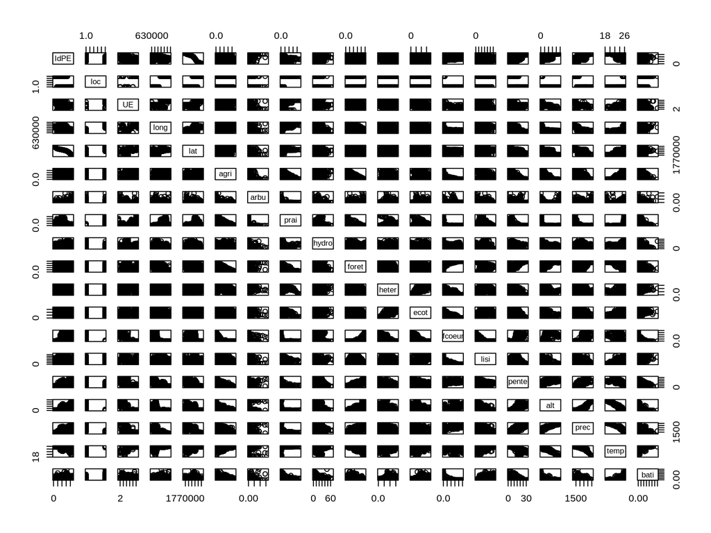

```r
plot(habitat)
```

```r
res = chisq.test(habitat[,4:19]) ; res
```

```
##
##  Pearson's Chi-squared test
##
## data:  habitat[, 4:19]
## X-squared = 690042, df = 13695, p-value < 2.2e-16
```

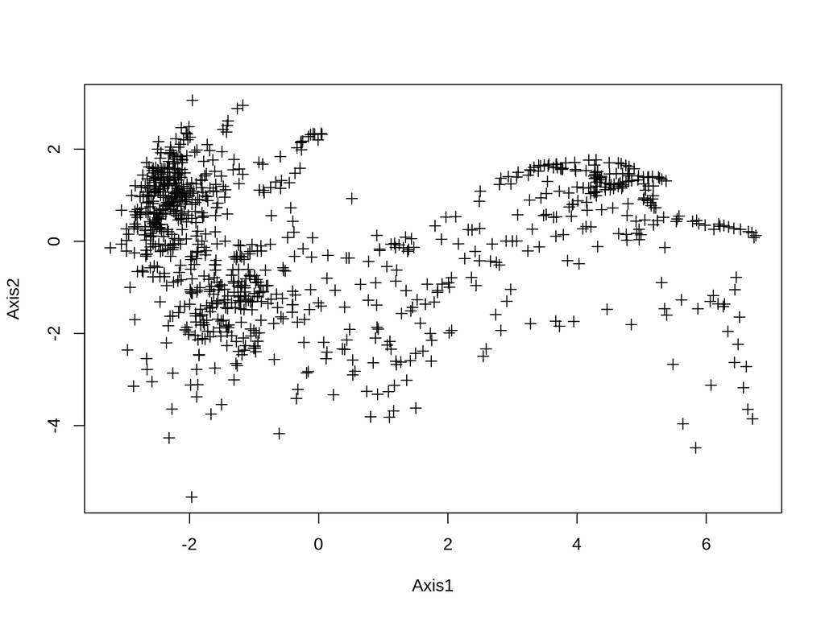

```r
# Dépendance des données

acp_habitat = dudi.pca(habitat[,4:19], scale=T, nf = 2, scannf = F)
plot(acp_habitat$li,
     pch = 3)
```

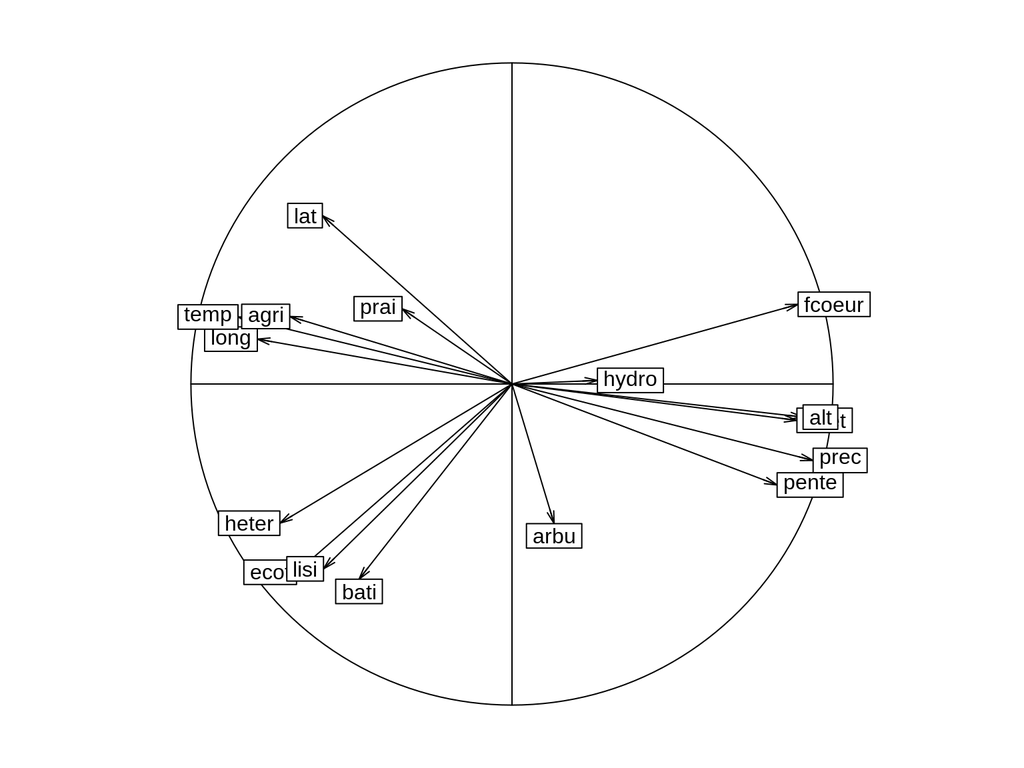

```r
s.corcircle(acp_habitat$co,
            grid = F)
```

```r
acp_habitat$c1
```

```
##                CS1          CS2
## long   -0.28220786  0.096503992
## lat    -0.21011116  0.361947976
## agri   -0.24629728  0.145164973
## arbu    0.04667534 -0.300078275
## prai   -0.12185444  0.161730500
## hydro   0.09465626  0.007728365
## foret   0.31571473 -0.078104816
## heter  -0.25723888 -0.299136122
## ecot   -0.23874791 -0.404577352
## fcoeur  0.31705334  0.171227746
## lisi   -0.20887190 -0.397278555
## pente   0.29376299 -0.217028999
## alt     0.32254790 -0.071134350
## prec    0.33365837 -0.164285853
## temp   -0.30359650  0.144051605
## bati   -0.16950428 -0.419555865
```

```r
# 1 variable expliquant peu le modèle : hydro (faible pourcentage d'explication des axes, <10%)
```

# AFC sur répartition des espèces (commu)

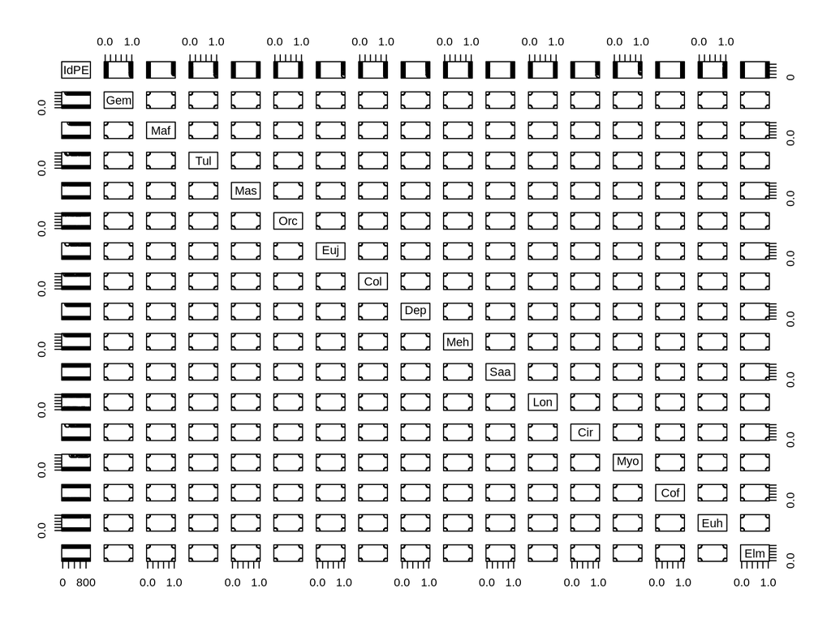

```r
plot(commu)
```

```r
res = chisq.test(commu[,2:17]) ; res
```

```
##
##  Pearson's Chi-squared test
##
## data:  commu[, 2:17]
## X-squared = 8237.7, df = 13695, p-value = 1
```

```r
# Indépendance des données

afc1 = dudi.coa(commu[,-1], nf=2, scannf = F) ; afc1
```

```
## Duality diagramm
## class: coa dudi
## $call: dudi.coa(df = commu[, -1], scannf = F, nf = 2)
##
## $nf: 2 axis-components saved
## $rank: 15
## eigen values: 0.3929 0.1814 0.1501 0.1374 0.1232 ...
##   vector length mode    content
## 1 $cw    16     numeric column weights
## 2 $lw    914    numeric row weights
## 3 $eig   15     numeric eigen values
##
##   data.frame nrow ncol content
## 1 $tab       914  16   modified array
## 2 $li        914  2    row coordinates
## 3 $l1        914  2    row normed scores
## 4 $co        16   2    column coordinates
## 5 $c1        16   2    column normed scores
## other elements: N
```

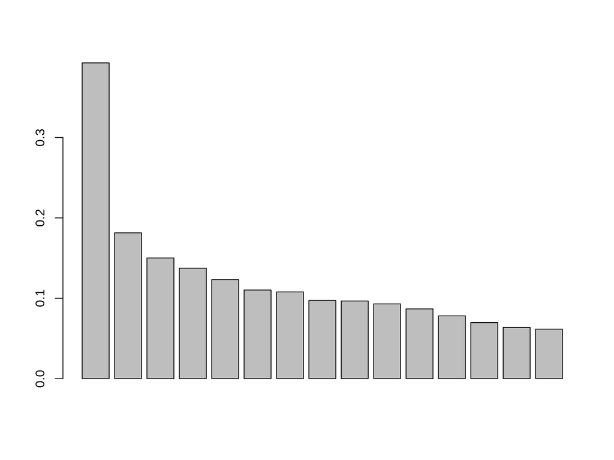

```r
barplot(afc1$eig)
```

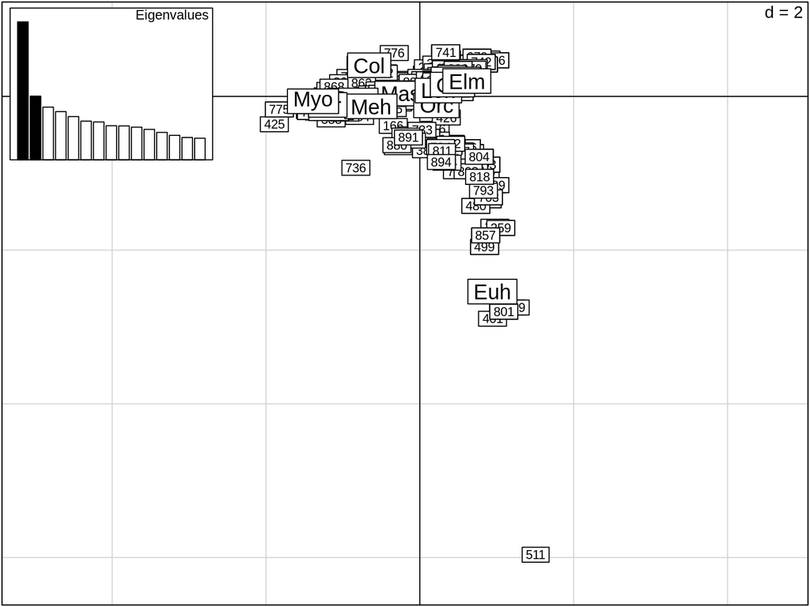

```r
scatter(afc1)
```

# Couplage de tableaux entre AFC (tableau espèce) et une ACP normée (tableau habitat)

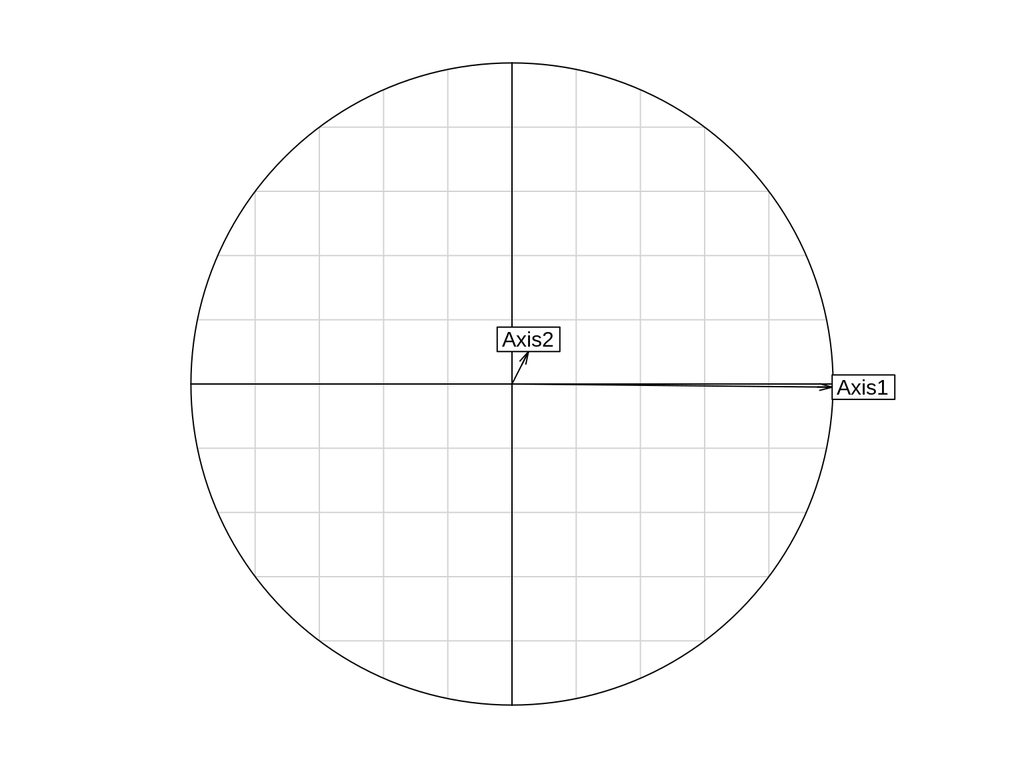

```r
# Log des données
caract_habitat = habitat[,-(1:3)]
log_habitat = log(caract_habitat +1)

cca = pcaiv(afc1, log_habitat, scannf = F, nf = 2)

#projection axe d'inertie
s.corcircle(cca$as)
```

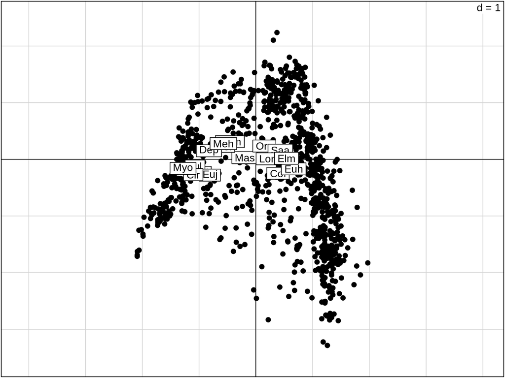

```r
# Position des relevés par combinaisons de variables environnementales : représentation des sites
s.label(cca$l1, clabel = 0, cpoint = 1.5)

# Position des espèces à la moyenne des sites qui les contiennent : représentation des espèces
s.label(cca$co, add.plot = T)
```

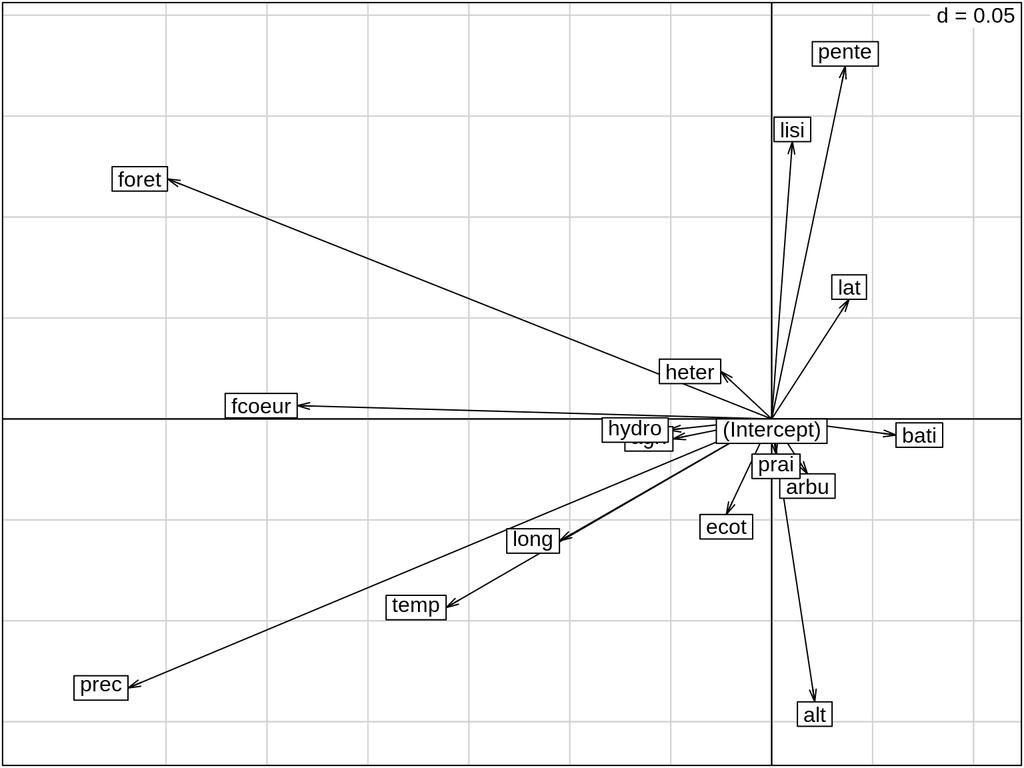

```r
# Poids canoniques donnant les combinaisons de variance unité
s.arrow(cca$fa)
```

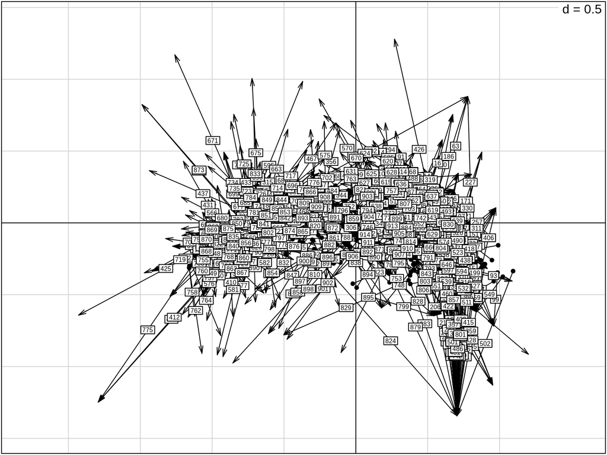

```r
# Prédiction des positions par régression sur les variables de milieu
s.match(cca$li, cca$ls, clabel = 0.5)
```

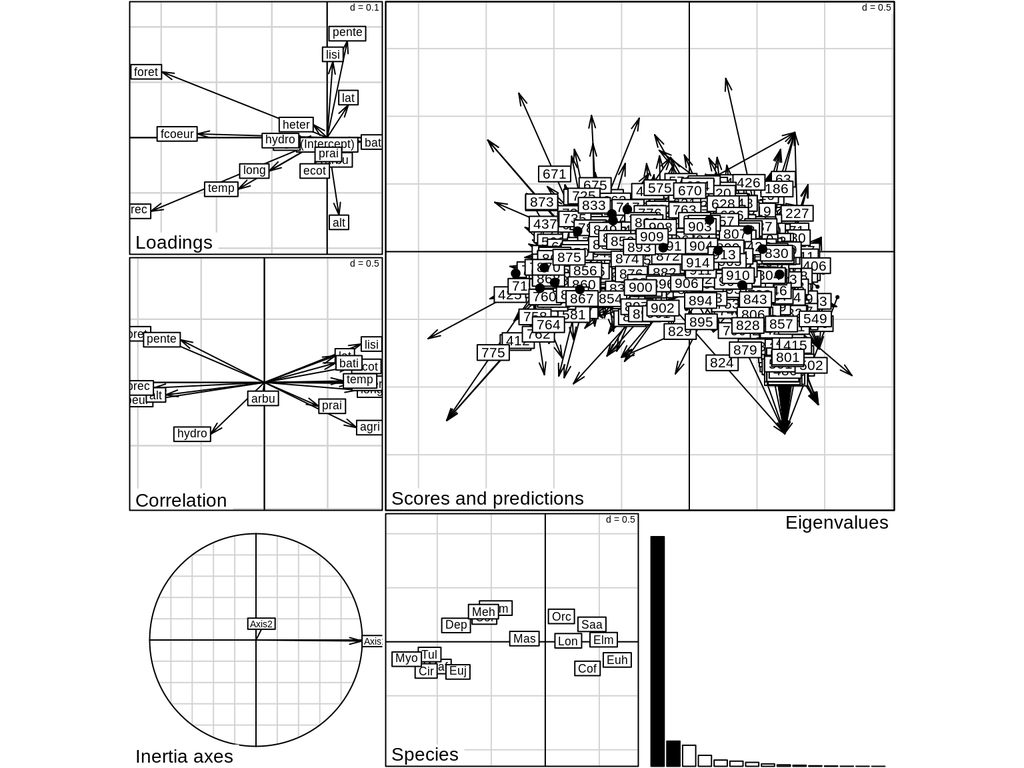

```r
# Ensemble des résultats de l'analyse
plot(cca)
```